# AUTOMATIZAÇÃO DE AJUSTES HIPSOMÉTRICOS POR PARCELA

Fabiano Rodrigues Pereira

09/10/2022

BASE DE DADOS OBTIDA DE PLANTIOS DE *Eucalyptus urophylla*, CLONE AEC 0144

# CARREGANDO E EXPLORANDO OS DADOS

## Carregando pacotes

```r
library(ggplot2)
library(tidyr)
```

## Carregando arquivo com medições de campo

```r
MDADOS <- read.table('dados.txt', header = T)
head(MDADOS, 20)
```

```
##    parcela arvore  dap   ht
## 1        1      1  8.0 13.2
## 2        1      2  5.8 12.4
## 3        1      3  9.2 14.3
## 4        1      4  7.9 12.6
## 5        1      5  5.6 12.8
## 6        1      6  8.4 14.3
## 7        1      7  6.2 11.7
## 8        1      8  9.2 14.2
## 9        1      9  8.6 14.8
## 10       1     10  6.7 15.6
## 11       1     11  8.3 15.3
## 12       1     12 11.7 16.5
## 13       1     13  6.5 12.4
## 14       1     14 11.6 15.3
## 15       1     15  6.3  0.0
## 16       1     16  5.7  0.0
## 17       1     17  9.2  0.0
## 18       1     18  4.3  0.0
## 19       1     19  6.8  0.0
## 20       1     20  8.0  0.0
```

## Carregando arquivo com modelos:

### Modelo 1:

$ht_i = \beta_0 + \beta_1 dap_i + \epsilon_i$

### Modelo 2:

$ht_i = \beta_0 + \beta_1 \frac{1}{dap_i} + \epsilon_i$

### Modelo 3:

$ht_i = \beta_0 + \beta_1 dap_i^2 + \epsilon_i$

### Modelo 4:

$ht_i = \beta_0 + \beta_1 dap_i + \beta_2 dap_i^2 + \epsilon_i$

```r
MODELOS <- read.table('modelos_hip.txt', header = T)
print(MODELOS)
```

```
##        modelo
## 1      ht~dap
## 2   ht~invdap
## 3     ht~dap2
## 4 ht~dap+dap2
```

## Dispersão gráfica do diâmetro à altura do peito (dap) vs altura das árvores em que as alturas foram medidas

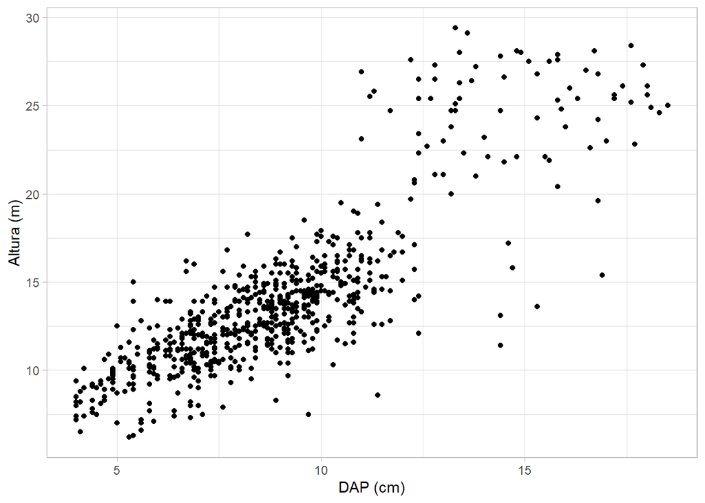

```r
MDADOS[MDADOS$ht != 0, ] %>% ggplot(aes(dap, ht))+
  geom_point()+
  ylab('Altura (m)')+
  xlab('DAP (cm)')+
  theme_light()
```

## Transformação das variáveis para os ajustes

```r
MDADOS$invdap <- 1/(MDADOS$dap)
MDADOS$dap2 <- (MDADOS$dap)^2
head(MDADOS)
```

```
##   parcela arvore dap   ht    invdap  dap2
## 1       1      1 8.0 13.2 0.1250000 64.00
## 2       1      2 5.8 12.4 0.1724138 33.64
## 3       1      3 9.2 14.3 0.1086957 84.64
## 4       1      4 7.9 12.6 0.1265823 62.41
## 5       1      5 5.6 12.8 0.1785714 31.36
## 6       1      6 8.4 14.3 0.1190476 70.56
```

# PROCESSAMENTO DOS DADOS

## Criando matriz de saida com apenas cabeçalho para receber os valores *PARC | ARVORE | DAP | HT*

```r
MSAIDA <- matrix(nrow = 0, ncol = ncol(MDADOS))
```

## Transformando matrix da saida 1 em dataframe

```r
MSAIDA <- as.data.frame(MSAIDA)
names(MSAIDA) <- c("PARC", "ARV", "DAP", "HT")
```

## Criando matriz de saida 2 para receber os valores *PARC | MODELO | ERRO*

```r
MSAIDA2 <- matrix(nrow = NROW(unique(MDADOS$parcela))*NROW(MODELOS), ncol = 3, 0)
```

## Transformando matrix de saida 2 em dataframe

```r
MSAIDA2 <- as.data.frame(MSAIDA2)
names(MSAIDA2) <- c("PARC", "MODELO", "ERRO")
```

## Ajustando 4 modelos para cada parcela, verificando o erro e selecionando o de menor erro

```r
nlinha <- 0 # Definindo numero atual da linha da tabela de erros dos modelos

for (i in unique(MDADOS$parcela)) { # Filtrando por parcela

  MTEMP1 <- MDADOS[MDADOS$parcela == i & MDADOS$ht != 0,] # Criando base com arvores medidas
  MTEMP2 <- MDADOS[MDADOS$parcela == i & MDADOS$ht == 0,] # Criando base com arvores nao medidas

  if(nrow(MTEMP2) != 0){ # Verificando se ha arvores nao medidas

    ERRO_ANTERIOR <- Inf # Definindo primeiro erro com infinito (para sempre considerar o primeiro modelo) para iniciar comparações de modelo por parcela

    for (k in 1:nrow(MODELOS)) { # Ajustando modelos por parcela
      nlinha <- nlinha + 1 # Atualizando o número de linhas da tabela de erros
      AJUSTE_ATUAL <- lm(MODELOS$modelo[k], MTEMP1) # Realizando ajuste do modelo k da parcela i
      ESTAT_ATUAL <- summary(AJUSTE_ATUAL) # Extraindo esttística do modelo k da parcela i
      MSAIDA2$PARC[nlinha] <- i # Adicionando valor da parcela i a tabela de erro dos modelos
      MSAIDA2$MODELO[nlinha] <- k # Adicionando numero do modelo k a tabela de erro dos modelos
      MSAIDA2$ERRO[nlinha] <- ESTAT_ATUAL$sigma # Adicionando valor de erro a tabela de erro dos modelos
      ERRO_ATUAL <- ESTAT_ATUAL$sigma # Extraindo o valor do erro do modelo atual (k)

      if(ERRO_ATUAL < ERRO_ANTERIOR){ # Verificando se o erro do modelo atual (k) é menor que o do anteior (k-1)

        MELHOR_AJUSTE <- AJUSTE_ATUAL # Se a condicao for atendida, o modelo atual e considerado o melhor ajuste

      }

      ERRO_ANTERIOR <- ERRO_ATUAL # Atualizando o valor do erro anterior (k-1) para o proximo valor de k

    }

    MTEMP2$ht <- predict(MELHOR_AJUSTE, newdata = MTEMP2) # Adicionando predicoes a tabela de arvores nao medidas

    PARCELA_AJUSTADA <- rbind(MTEMP1, MTEMP2) # Unindo tabelas de arvores de alturas medidas com estimadas

    PARCELA_AJUSTADA <- PARCELA_AJUSTADA[order(PARCELA_AJUSTADA$arvore),1:4] # Ordenando valores da parcela ajustada pelo n da arvore

    MSAIDA <- rbind(MSAIDA, PARCELA_AJUSTADA) # Adicionando parcela ajustada a tabela de saida
  }

}
```

# SAIDA

## Base de dados com todas alturas não medidas estimadas por modelos ajustados para cada parcela

```r
head(MSAIDA, 20)
```

```
##    parcela arvore  dap       ht
## 1        1      1  8.0 13.20000
## 2        1      2  5.8 12.40000
## 3        1      3  9.2 14.30000
## 4        1      4  7.9 12.60000
## 5        1      5  5.6 12.80000
## 6        1      6  8.4 14.30000
## 7        1      7  6.2 11.70000
## 8        1      8  9.2 14.20000
## 9        1      9  8.6 14.80000
## 10       1     10  6.7 15.60000
## 11       1     11  8.3 15.30000
## 12       1     12 11.7 16.50000
## 13       1     13  6.5 12.40000
## 14       1     14 11.6 15.30000
## 15       1     15  6.3 13.01501
## 16       1     16  5.7 12.78643
## 17       1     17  9.2 14.44203
## 18       1     18  4.3 12.34198
## 19       1     19  6.8 13.22295
## 20       1     20  8.0 13.78678
```

## Tabela com valores de erro de cada modelo ajustado para cada parcela para conferência

```r
head(MSAIDA2, 10)
```

```
##    PARC MODELO      ERRO
## 1     1      1 1.0269709
## 2     1      2 1.0469112
## 3     1      3 1.0397667
## 4     1      4 1.0719356
## 5     2      1 0.5585310
## 6     2      2 0.5526454
## 7     2      3 0.5618497
## 8     2      4 0.5682350
## 9     3      1 0.5235153
## 10    3      2 0.5379703
```

## Modelos ajustados para toda a base de dados de uma vez

```r
MODELO_GERAL <- data.frame(Modelo = 1:4, Erro = c(summary(lm(MODELOS$modelo[1],MDADOS[MDADOS$ht != 0, ]))$sigma,
summary(lm(MODELOS$modelo[2],MDADOS[MDADOS$ht != 0, ]))$sigma,
summary(lm(MODELOS$modelo[3],MDADOS[MDADOS$ht != 0, ]))$sigma,
summary(lm(MODELOS$modelo[4],MDADOS[MDADOS$ht != 0, ]))$sigma))
MODELO_GERAL
```

```
##   Modelo     Erro
## 1      1 2.468605
## 2      2 3.146877
## 3      3 2.468917
## 4      4 2.439392
```

## Visualizando os erros de todos os modelos ajustados para cada parcela e comparando com o menor erro obtido considerando a base de dados completa (linha horizontal vermelha), é possível observar que os ajutes por parcela apresentaram em grande maioria menores erros.

## Ainda, em caso de erros muito altos, pode-se verificá-los de forma mais detalhada para a validação das informações.

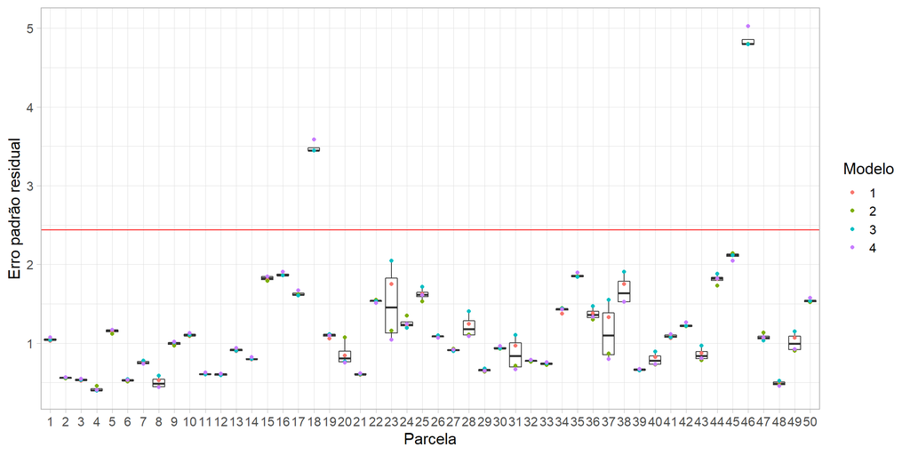

```r
MSAIDA2 %>% ggplot(aes(factor(PARC), ERRO))+
  geom_boxplot()+
  geom_point(aes(color = factor(MODELO)))+
  geom_hline(yintercept = min(MODELO_GERAL$Erro), color = "red")+
  labs(x = 'Parcela', y = 'Erro padrão residual', color = "Modelo")+
  theme_light(15)
```